# Risk group gene expression analysis

Hedda Fjell Scheel

2025-02-09

# Contents

In this document we will:

1. Divide cohort in to high and low risk groups + look at which clinical variables characterize the groups
2. Do differential gene expression analysis (low risk vs high risk) and plot results. Significance level: p-adj=FDR=0.05
3. Do a gene set enrichment analysis using fgsea. Significance level BH (Benjamini-Hochberg) adjusted p-value=FDR= 0.05

## Making risk based groups

```r
load("data/tumor_samples_with_subtype.Rdata")

#make clinical onehot
clin_vars <- c("Age", "Neuter_status", "Grade", "Lymphatic_invasion", "ER_status", "HER2_score", "Breed_Maltese", "Malignitet", "subtype_MPAM50", "Breed", "Histology")
data_for_table <- tumor_samples_with_subtype %>%
  mutate(subtype_MPAM50 = as.factor(subtype_MPAM50)) %>%
  kNN(variable = clin_vars, k=5) %>%
  drop_na("Survival_days") %>%
  select(c(Sample_ID, all_of(clin_vars), Status_survival, Survival_days)) %>%
  # Only keeping variables we will use
  as_tibble()

clin_vars = c("Age", "ER_status", "Lymphatic_invasion")

clinical_tbl <- tumor_samples_with_subtype %>%
  mutate(subtype_MPAM50 = as.factor(subtype_MPAM50)) %>%
  kNN(variable = clin_vars, k=5) %>%
  drop_na("Survival_days") %>%
  mutate(Age = as.vector(scale(Age))) %>%
  select(c(Sample_ID, all_of(clin_vars), Status_survival, Survival_days)) %>%
  # Only keeping variables we will use
  as_tibble()

# Making treatment contrast groups
clinical_onehot <- clinical_tbl %>%
  mutate(ER_positive = ifelse(ER_status == "N", 0, 1)) %>%
  mutate(Lymphatic_invasion_present = ifelse(Lymphatic_invasion == "Absent", 0, 1)) %>%
  select(-ER_status, -Lymphatic_invasion)

# Fitting the Clinical model on all dogs to get betas to predict from
Cox.clinical <- coxph(Surv(Survival_days, Status_survival) ~ Age +  ER_positive + Lymphatic_invasion_present, data = clinical_onehot)
Predicted_risk_multivariate_clinical <- tibble(Sample_ID = clinical_onehot$Sample_ID, Predicted_risk= Cox.clinical$linear.predictors) %>% column_to_rownames("Sample_ID")
```

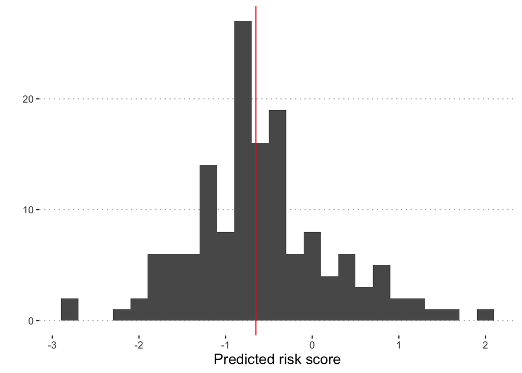

```r
#distribution of risk scores
risk_histogram <- ggplot(data = Predicted_risk_multivariate_clinical, aes(Predicted_risk))+
  geom_histogram(binwidth = 0.2)+
  geom_vline(xintercept = -0.65, color = "red")+
  theme_pubclean()+
  xlab("Predicted risk score")+
  ylab("")+
  theme(axis.title=element_text(size=14))
risk_histogram
```

```r
ggsave(risk_histogram,file="plots/risk_histogram_2025_01_20_one_model.jpeg", height = 4, width = 6.4)

range(Predicted_risk_multivariate_clinical$Predicted_risk)
```

```
## [1] -2.739613  1.963318
```

```r
median(Predicted_risk_multivariate_clinical$Predicted_risk)
```

```
## [1] -0.6041138
```

```r
#Stratifying cohort into low-risk and high-risk groups
high_risk_dogs <- Predicted_risk_multivariate_clinical %>%
  filter(Predicted_risk>=median(Predicted_risk_multivariate_clinical$Predicted_risk)) %>%
  rownames()
low_risk_dogs <- Predicted_risk_multivariate_clinical %>%
  filter(Predicted_risk<median(Predicted_risk_multivariate_clinical$Predicted_risk)) %>%
  rownames()

# adding risk-info to clinical onehot and clinical_tbl
clinical_onehot <- clinical_onehot %>%
  mutate("Risk_group_high" = ifelse(clinical_onehot$Sample_ID %in% high_risk_dogs, 1, 0))

clinical_tbl <- clinical_tbl %>%
  mutate("Risk_group" = ifelse(clinical_onehot$Sample_ID %in% high_risk_dogs, "high", "low"))
data_for_table<- data_for_table %>%
  mutate("Risk_group" = ifelse(clinical_onehot$Sample_ID %in% high_risk_dogs, "high", "low"))
```

### Group differences in survival

```r
# Univariate cox to get Hazard ratio
coxph(Surv(Survival_days, Status_survival) ~ Risk_group_high, data = clinical_onehot)
```

```
## Call:
## coxph(formula = Surv(Survival_days, Status_survival) ~ Risk_group_high,
##     data = clinical_onehot)
##
##                   coef exp(coef) se(coef)     z       p
## Risk_group_high 0.9845    2.6764   0.3511 2.804 0.00505
##
## Likelihood ratio test=8.54  on 1 df, p=0.003472
## n= 146, number of events= 38
```

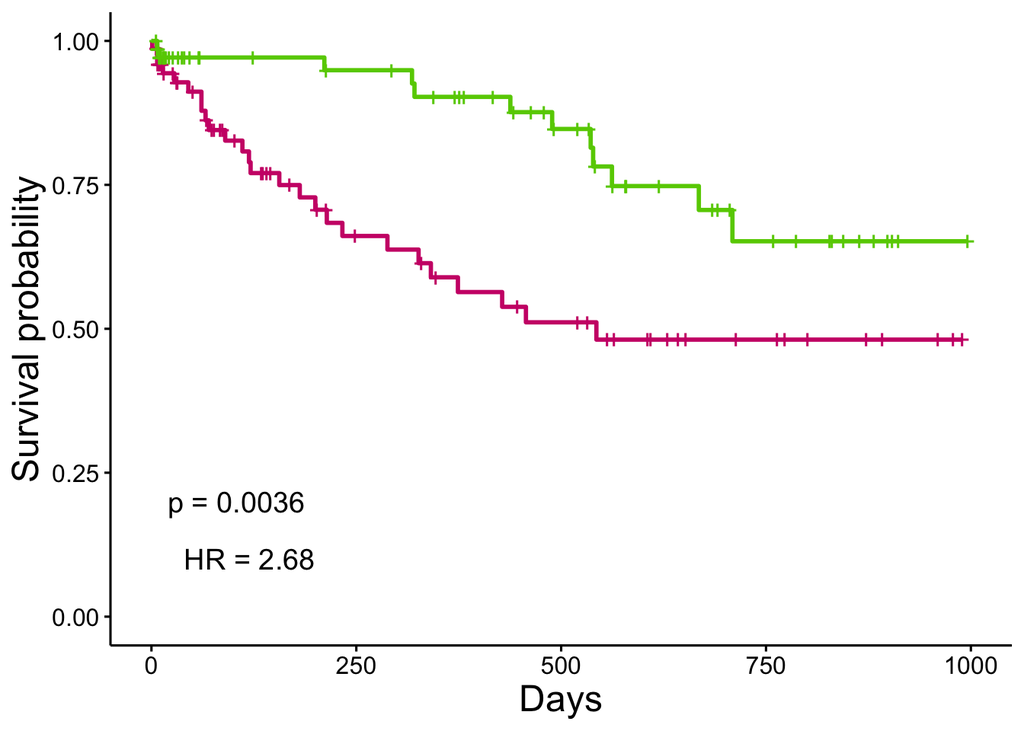

```r
# KM plot of the risk groups
fitrisk <- survfit(Surv(clinical_tbl$Survival_days, clinical_tbl$Status_survival)~Risk_group, data=clinical_tbl)
riskKM.plot <- ggsurvplot(fitrisk, data=clinical_tbl,
                        pval = T,
                        conf.int=F,
                        legend="none",
                        palette= c("deeppink3", "chartreuse3"),
                        font.title = 25,
                        font.x = 18,
                        font.y = 18,
                        xlab = "Days")

riskKM.plot$plot <- riskKM.plot$plot +
                     ggplot2::annotate("text",
                                x = 120, y = 0.1, # x and y coordinates of the text
                                label = "HR = 2.68", size = 5)

ggsave(file = "plots/riskKM.plot.one_model.png", plot= print(riskKM.plot$plot), height = 4.1, width = 5.7)
```

### Clinical variables’ relation to risk groups

```r
tablerisk <- table_descriptive <- tableby(Risk_group ~ Age + Breed_Maltese + Neuter_status + subtype_MPAM50 + Lymphatic_invasion + ER_status +  HER2_score +Grade, data = data_for_table)
# labels(table_descriptive) <- c(Neuter_status = "Neuter status", Breed_Maltese = "Breed group", Lymphatic_invasion = "Lymphatic invasion", ER_status = "ER status", HER2_score = "HER2 score", subtype_MPAM50 = "MPAM50 Subtype") # Does not work
summary(tablerisk)
```

|  | high (N=74) | low (N=72) | Total (N=146) | p value |
| --- | --- | --- | --- | --- |
| **Age** |  |  |  | < 0.001 |
| Mean (SD) | 13.851 (1.576) | 9.847 (2.324) | 11.877 (2.816) |  |
| Range | 10.000 - 19.000 | 2.000 - 12.000 | 2.000 - 19.000 |  |
| **Breed_Maltese** |  |  |  | 0.229 |
| Maltese | 18 (24.3%) | 24 (33.3%) | 42 (28.8%) |  |
| Non-Maltese | 56 (75.7%) | 48 (66.7%) | 104 (71.2%) |  |
| **Neuter_status** |  |  |  | 0.006 |
| Intact | 43 (58.1%) | 57 (79.2%) | 100 (68.5%) |  |
| Neutered | 31 (41.9%) | 15 (20.8%) | 46 (31.5%) |  |
| **subtype_MPAM50** |  |  |  | 0.002 |
| Basal | 40 (54.1%) | 21 (29.2%) | 61 (41.8%) |  |
| LumA | 34 (45.9%) | 51 (70.8%) | 85 (58.2%) |  |
| **Lymphatic_invasion** |  |  |  | < 0.001 |
| Absent | 59 (79.7%) | 72 (100.0%) | 131 (89.7%) |  |
| Present | 15 (20.3%) | 0 (0.0%) | 15 (10.3%) |  |
| **ER_status** |  |  |  | < 0.001 |
| N | 21 (28.4%) | 2 (2.8%) | 23 (15.8%) |  |
| P | 53 (71.6%) | 70 (97.2%) | 123 (84.2%) |  |
| **HER2_score** |  |  |  | 0.094 |
| 0 | 8 (10.8%) | 3 (4.2%) | 11 (7.5%) |  |
| 1 | 16 (21.6%) | 10 (13.9%) | 26 (17.8%) |  |
| 2 | 30 (40.5%) | 43 (59.7%) | 73 (50.0%) |  |
| 3 | 20 (27.0%) | 16 (22.2%) | 36 (24.7%) |  |
| **Grade** |  |  |  | < 0.001 |
| Benign | 7 (9.5%) | 26 (36.1%) | 33 (22.6%) |  |
| 1 | 31 (41.9%) | 34 (47.2%) | 65 (44.5%) |  |
| 2 | 12 (16.2%) | 10 (13.9%) | 22 (15.1%) |  |
| 3 | 24 (32.4%) | 2 (2.8%) | 26 (17.8%) |  |

## Differential gene expression

### DESeq2 analysis - comparing low-risk and high-risk groups

We will follow the workflow described in the DESeq2 vignette. http://bioconductor.org/packages/devel/bioc/vignettes/DESeq2/inst/doc/DESeq2.html#why-after-vst-are-there-still-batches-in-the-pca-plot . Low-risk is set to reference level.

```r
load("data/counts_tumors.Rdata")
counts_tumors <- counts_tumors %>%
  select(clinical_tbl$Sample_ID)
# Formatting gene names to syntactically valid names
rownames(counts_tumors) <- make.names(rownames(counts_tumors))

# Normalizing count data with DESeq2.
# Used clinical_tbl(which has the original variables) and not the clinical_onehot.
dds_tumor <- DESeqDataSetFromMatrix(countData = counts_tumors,
                                    colData = clinical_tbl,
                                    design = ~ Risk_group)


dds_tumor$Risk_group <- relevel(dds_tumor$Risk_group, ref = "low") #Setting low-riak as the reference level

### Pre-filtering: not necessary but recommended since it will decrease run time and memory size dds_tumor ------
keep <- rowSums(counts(dds_tumor)) >= 10
dds_tumor <- dds_tumor[keep,]

dds_tumor <- DESeq(dds_tumor)
```

```
## -- replacing outliers and refitting for 2013 genes
## -- DESeq argument 'minReplicatesForReplace' = 7
## -- original counts are preserved in counts(dds)
```

```r
res <- results(dds_tumor)
```

### DGE list for all genes (significant and non-significant)

```r
datatable(as.data.frame(res), options = list(pageLength = 12, scrollX = T), caption = htmltools::tags$caption(style = 'caption-side: top; text-align: left;', 'Differential gene expression list'))
```

|  | baseMean | log2FoldChange | lfcSE | stat | pvalue | padj |
| --- | --- | --- | --- | --- | --- | --- |
| A1BG | 78.2056305824333 | -0.331152311397514 | 0.215512294731983 | -1.536581993196 | 0.124395704904671 | 0.337439548138238 |
| A1CF | 0.24493229321279 | 0.80225409141908 | 2.3029524057959 | 0.34835895409737 | 0.727570624118037 | 0.877821168146664 |
| A2ML1 | 14.0746105727296 | 0.942493281614746 | 0.369026515083695 | 2.55399881333998 | 0.0106493619477308 | 0.0722604303171556 |
| A3GALT2 | 36.4893087658986 | 0.140061242492377 | 0.255793763131933 | 0.547555346062666 | 0.583997257751818 | 0.794734141796018 |
| A4GALT | 1661.60570301533 | 0.0575222331592677 | 0.195628757796513 | 0.29403771616799 | 0.768729083245604 | 0.899766130937491 |
| A4GNT | 7.33950294027161 | 0.710900872153851 | 0.379701173871056 | 1.87226408837827 | 0.0611700764547408 | 0.222037922523 |
| AAAS | 2135.49141391896 | 0.0810251536446435 | 0.075819253097819 | 1.06866198668705 | 0.285222006241677 | 0.546284879211303 |
| AACS | 1321.72678021198 | 0.38390739366573 | 0.13180879419446 | 2.91260834310754 | 0.0035842383852738 | 0.0345098901359605 |
| AADAC | 6.71431229556242 | -0.178295185973451 | 0.493121604005939 | -0.361564337325817 | 0.717677618751804 | 0.87324393021914 |
| AADACL2 | 0.81067236478603 | 0.188604254073925 | 0.767031584423732 | 0.245888510856593 | 0.805768537850507 | 0.917786390764726 |

[output cut: 16992 more lines]

```r
res_save <- res %>% as.data.frame() %>% rownames_to_column(var = "Gene_name")
openxlsx::write.xlsx(res_save, 'plots/results_DGE_one_model.xlsx')
```

### Summary of results

With FDR= 0.05 and log2FoldChange > 1 or < -1, there are 433 differentially expressed genes. 279 genes were enriched in the high-risk group and 154 genes were enriched in the low-risk group

```r
res05 <- results(dds_tumor, alpha=0.05)
sum(res05$padj < 0.05 & res05$log2FoldChange>1, na.rm=TRUE)
```

```
## [1] 279
```

```r
sum(res05$padj < 0.05 & res05$log2FoldChange<(-1), na.rm=TRUE)
```

```
## [1] 154
```

### Plots of result

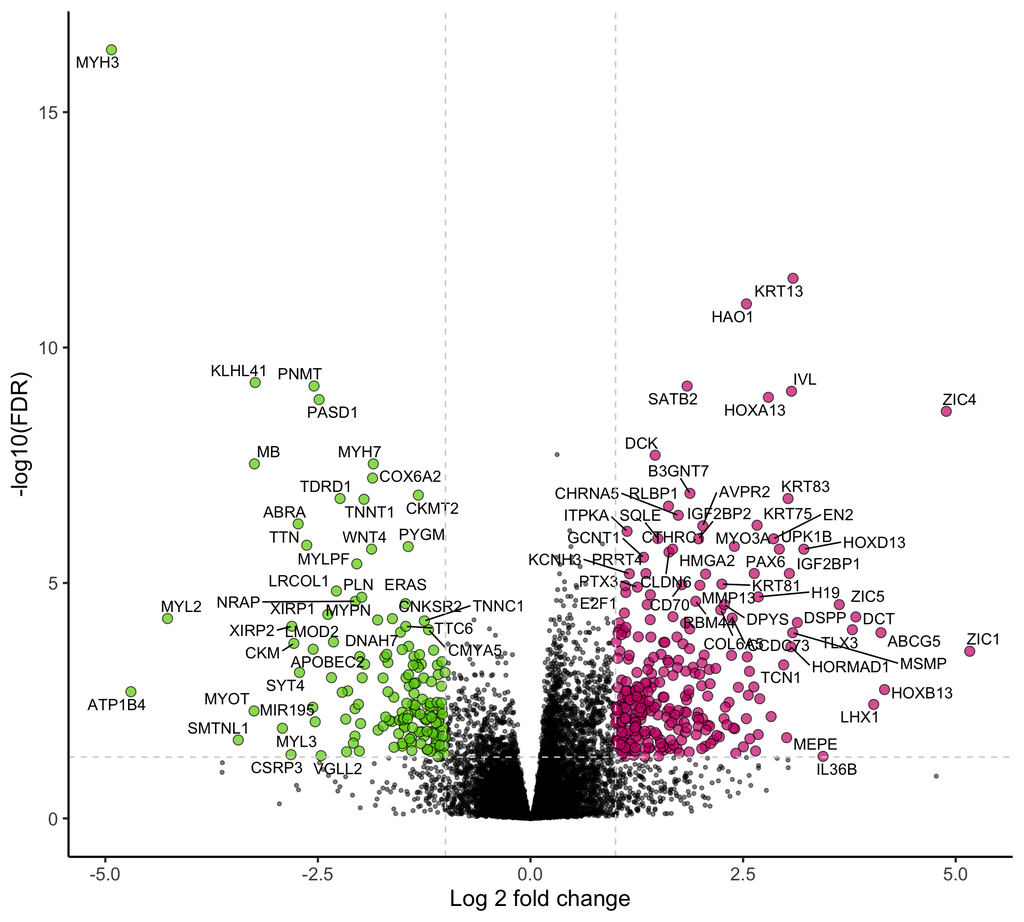

```r
diff_expr_results <- res %>% as.data.frame() %>% rownames_to_column(.,var = "GeneName")
sign <- res$padj < 0.05 & diff_expr_results$log2FoldChange < -1 | diff_expr_results$padj < 0.05 & diff_expr_results$log2FoldChange > 1
not_sign <- !sign
sign_low_risk <- diff_expr_results$padj < 0.05 & diff_expr_results$log2FoldChange < -1
sign_high_risk <- diff_expr_results$padj < 0.05 & diff_expr_results$log2FoldChange > 1

volcano_tumor <- ggplot(diff_expr_results, aes(log2FoldChange, -log10(padj)))+
  geom_point(data = diff_expr_results[not_sign,],alpha = 0.5, size = 1)+
  geom_point(data = diff_expr_results[sign_high_risk,], fill = "deeppink3",color = "black", size = 3, alpha = 0.7, shape = 21)+
  geom_point(data = diff_expr_results[sign_low_risk,], fill = "chartreuse3",color = "black", size = 3, alpha = 0.7, shape = 21)+
  geom_text_repel(label = diff_expr_results$GeneName[sign], data = diff_expr_results[sign,], max.overlaps = 15)+
  geom_hline(yintercept = -log10(0.05), color = "lightgrey", linetype = 2)+
  geom_vline(xintercept = c(-1,1), color = "lightgrey",  linetype = 2)+
  labs(x = "Log 2 fold change", y = "-log10(FDR)")+
  #lims(x = c(-2.5,2.5))+
  #ggtitle("DGE low-risk vs high-risk")+
  theme_classic2(base_size = 16)
volcano_tumor
```

```r
ggsave(file = "plots/Volcano.plot.one_model.png", plot= volcano_tumor, height = 7, width = 8)
```

## Gene set enrichment analysis

### GSEA using fgsea

I have used the approach for fgsea described on this website: https://stephenturner.github.io/deseq-to-fgsea/. I used the hallmark gene set for both analyses (as this set was recommended to start with) Codes for the bottom 4 plots are adapted from the fgsea vignette: https://bioconductor.org/packages/devel/bioc/vignettes/fgsea/inst/doc/fgsea-tutorial.html

#### 1. Load and tidy ranked gene list + load Msigdb gene set

```r
# Extracting two rows from the ranked gene list from DESeq2 (res), as we only need the gene name and test statistic.
res2 <- res %>%
  as_tibble(rownames = "gene_symbol") %>%
  dplyr::select(gene_symbol, stat)

#Loading hallmark pathways
pathways.hallmark <- gmtPathways("data/msigdb/msigdb_files/h.all.v2022.1.Hs.symbols.gmt")
```

#### 2. Run fgsea and tidy results

```r
## Run fgsea
ranks <- deframe(res2)

fgseaRes <- fgsea(pathways=pathways.hallmark, stats=ranks, nPermSimple=10000)

## Tidying: arrangring by descending NES
fgseaResTidy <- fgseaRes %>%
  as_tibble() %>%
  arrange(desc(NES))
```

#### 3. Results: table and plots

##### Table of GSEA results

The table below is ordered by descending normalized enrichment scores (NES).

```r
#Making the table
fgseaResTidy %>%
  dplyr::select(-leadingEdge, -ES) %>%
 # arrange(padj) %>% #include this to arrange by padj value
  datatable(. , options = list(pageLength = 12, scrollX = T), caption = htmltools::tags$caption(style = 'caption-side: top; text-align: left;', 'Top enriched pathways'))
```

|  | pathway | pval | padj | log2err | NES | size |
| --- | --- | --- | --- | --- | --- | --- |
| 1 | HALLMARK_E2F_TARGETS | 2.78900764381817e-41 | 1.39450382190908e-39 | 1.67199671627594 | 2.88281451135787 | 198 |
| 2 | HALLMARK_MYC_TARGETS_V1 | 4.84816109007812e-30 | 1.21204027251953e-28 | 1.42456271623384 | 2.6606036384955 | 198 |
| 3 | HALLMARK_G2M_CHECKPOINT | 1.29089205813037e-29 | 2.15148676355061e-28 | 1.40995143033448 | 2.65006017658802 | 198 |
| 4 | HALLMARK_MYC_TARGETS_V2 | 3.35024451767602e-12 | 2.79187043139669e-11 | 0.898671232061694 | 2.46437424208729 | 56 |
| 5 | HALLMARK_MTORC1_SIGNALING | 1.83494539715382e-14 | 1.92070486970496e-13 | 0.97599468306432 | 2.19828334195339 | 197 |
| 6 | HALLMARK_UNFOLDED_PROTEIN_RESPONSE | 1.72057387536926e-06 | 7.16905781403857e-06 | 0.643551836150722 | 1.91299202157179 | 112 |
| 7 | HALLMARK_DNA_REPAIR | 8.52431129796945e-08 | 6.08879378426389e-07 | 0.704975715167238 | 1.91016829647625 | 143 |
| 8 | HALLMARK_OXIDATIVE_PHOSPHORYLATION | 2.44090692116713e-07 | 1.52556682572946e-06 | 0.674962860011025 | 1.87210454780908 | 185 |
| 9 | HALLMARK_GLYCOLYSIS | 3.6616955603978e-07 | 2.03427531133211e-06 | 0.674962860011025 | 1.81525282806283 | 192 |
| 10 | HALLMARK_MITOTIC_SPINDLE | 5.05339770937042e-07 | 2.52669885468521e-06 | 0.659444398037935 | 1.81336100278006 | 198 |

[output cut: 40 more lines]

```r
openxlsx::write.xlsx(fgseaResTidy, 'plots/results_GSEA.xlsx')
```

##### Plotted enrichment scores

Plot the normalized enrichment scores. The color of the bar indicates whether or not the pathway was significantly enriched:

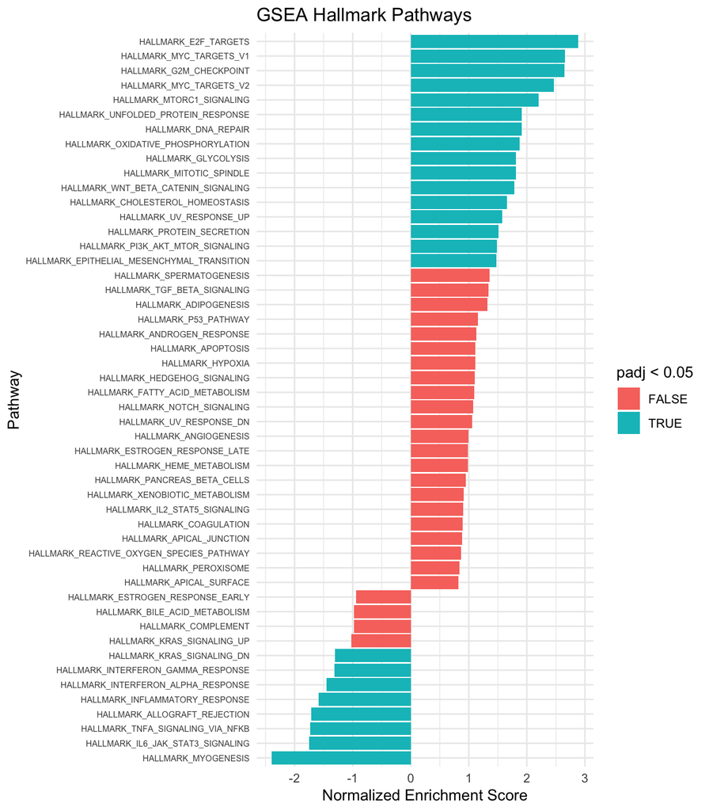

```r
ggplot(fgseaResTidy, aes(reorder(pathway, NES), NES)) +
  geom_col(aes(fill=padj<0.05)) +
  coord_flip() +
  labs(x="Pathway", y="Normalized Enrichment Score",
       title="GSEA Hallmark Pathways") +
  theme_minimal()+
  theme(axis.text.y = element_text(size = 6))
```

Plot of the significant pathways. Color indicates if the pathways are enriched in the low-risk group (green) or in the high-risk group (pink)

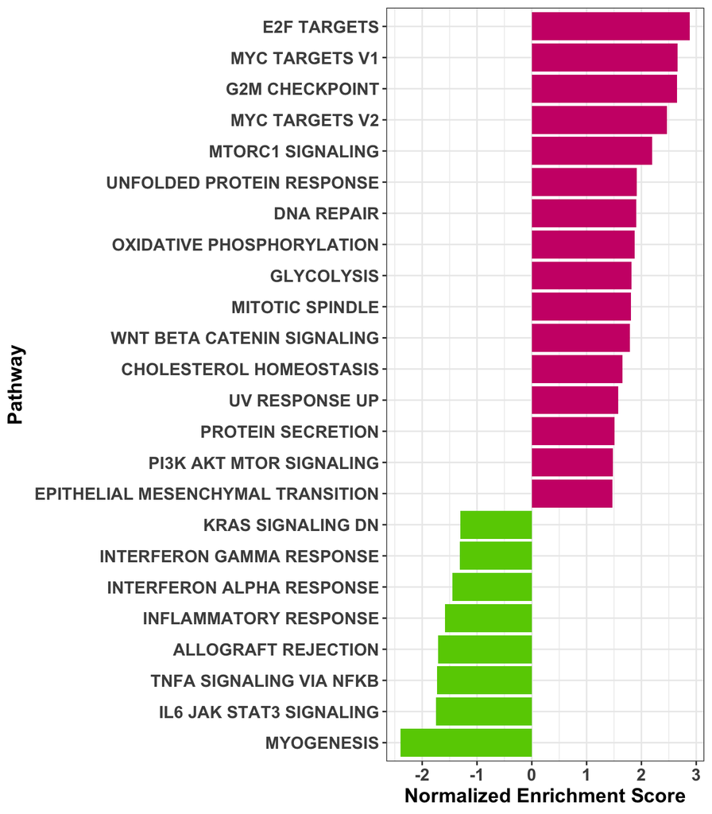

```r
significant_pathways <- fgseaResTidy %>%
                          filter(padj<0.05) %>%
                          mutate(pathway = str_replace_all(pathway, "_", " ")) %>%
                          mutate(pathway = str_remove_all(pathway, "HALLMARK"))

color = ifelse(significant_pathways$NES > 0, "deeppink3", "chartreuse3")
GSEA_plot <- ggplot(significant_pathways, aes(x = reorder(pathway, NES), y = NES)) +
  geom_bar(stat = "identity", fill = color, linewidth = 1)+ # evt: color = "black",
  coord_flip()+
  labs(x="Pathway", y="Normalized Enrichment Score") +
  theme_bw()+
  theme(axis.text = element_text(size = 12, face = "bold"), axis.title = element_text(size = 14, face = "bold"))
GSEA_plot
```

```r
ggsave(file = "plots/GSEA.plot.one_model.png", plot= GSEA_plot, height = 13, width = 10)
```

##### Enrichment plots

From the graph above, we can easily identify the top enriched pathway in high-risk tumors: Hallmark E2F targets. E2F targets include genes/proteins involved in initiation of replication, nucleotide synthesis and DNA synthesis. The enrichment plot for this pathway is plotted below:

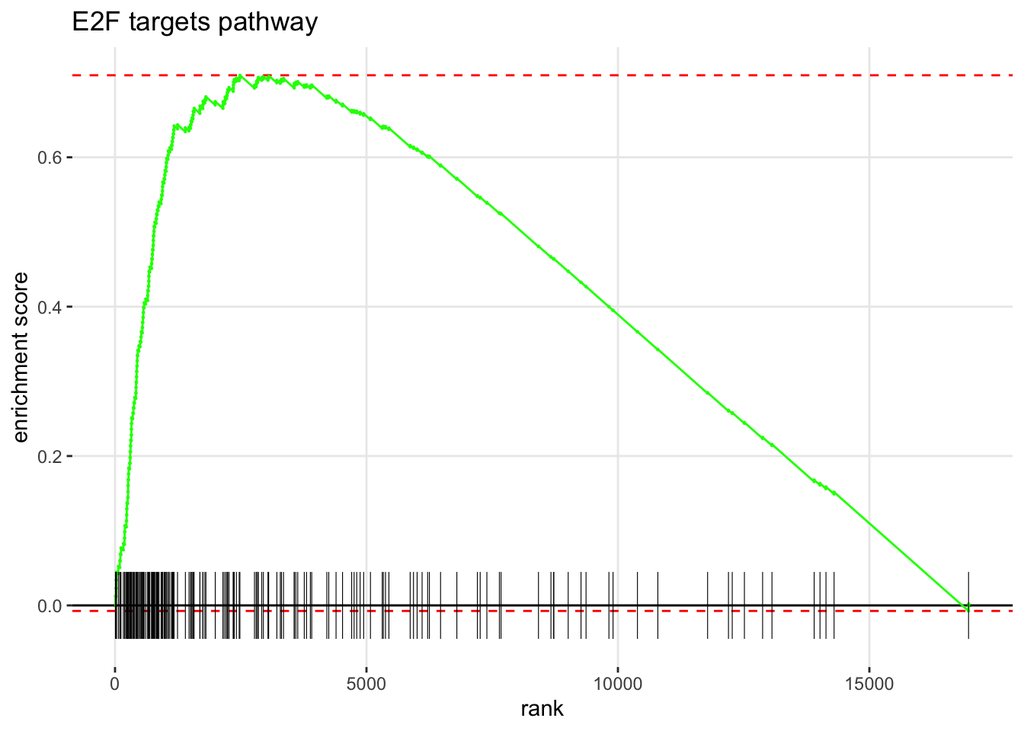

```r
plotEnrichment(pathways.hallmark[["HALLMARK_E2F_TARGETS"]],
               ranks) + labs(title="E2F targets pathway")
```

The top downregulated pathway in high-risk tumors is the myogenesis pathway.

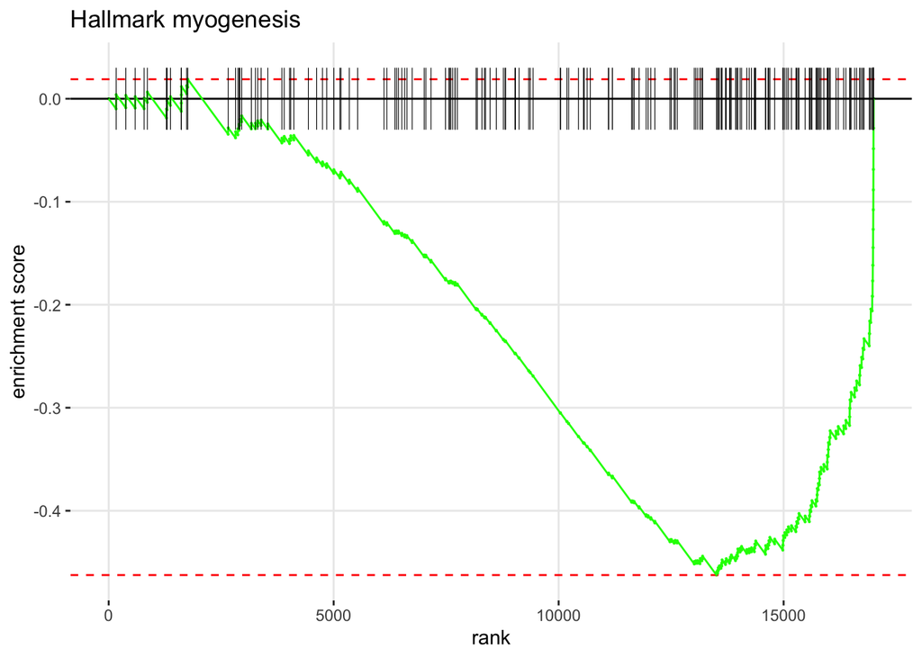

```r
plotEnrichment(pathways.hallmark[["HALLMARK_MYOGENESIS"]],
               ranks) + labs(title="Hallmark myogenesis")
```

##### Collapsed pathway plot

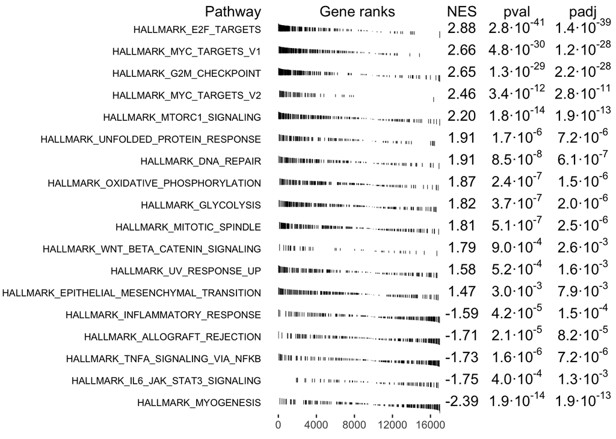

```r
collapsedPathways <- collapsePathways(fgseaRes[order(pval)][padj < 0.01],
                                      pathways.hallmark, ranks)
mainPathways <- fgseaRes[pathway %in% collapsedPathways$mainPathways][
  order(-NES), pathway]
plotGseaTable(pathways.hallmark[mainPathways], ranks, fgseaRes,
              gseaParam = 0.5,  pathwayLabelStyle = list(size=8))
```